# R Notebook

```r
library(dplyr)
library(tibble)
library(lubridate)
```

```r
library(readxl)
sportsref_download_6_ <- read_excel("Desktop/sportsref_download (6).xlsx")
AngelsAttendance <- sportsref_download_6_
#View(sportsref_download_6_)
```

```r
names(AngelsAttendance)
```

```
 [1] "Year"         "Tm"           "Lg"           "W"            "L"            "Finish"       "Playoffs"     "Attendance"
 [9] "Attend/G"     "Rank"         "Est. Payroll" "PPF"          "BPF"          "Stadium"
```

First I will create a new variable that shows the winning percentage:

```r
AngelsAttendance <- AngelsAttendance %>%
  mutate(WinPerc = round(W /(W + L), 2))
```

Replace NAs in Playoffs with “Missed Playoffs”

```r
AngelsAttendance$Playoffs[is.na(AngelsAttendance$Playoffs)] <- "Missed Playoffs"
```

We already know there was no attendance in 2020 due to the COVID-19 pandemic so we will ignore that season and also 2021 since a full crowd was not present until 2022.

2022-2025

```r
AngelsAtt2022to2025 <- AngelsAttendance %>% filter(Year %in% (2022:2025) )
```

Every season after the 2014 playoff appearance

```r
LAAattafterplayoffs <- AngelsAttendance %>% filter(Year >= 2014)
```

Excluding the COVID seasons

```r
AngelsAttNOCOVID <- AngelsAttendance %>% filter(!Year %in% c(2020, 2021))
LAAAttPlayoffsNoCOVID <- LAAattafterplayoffs %>% filter(!Year %in% c(2020, 2021))
```

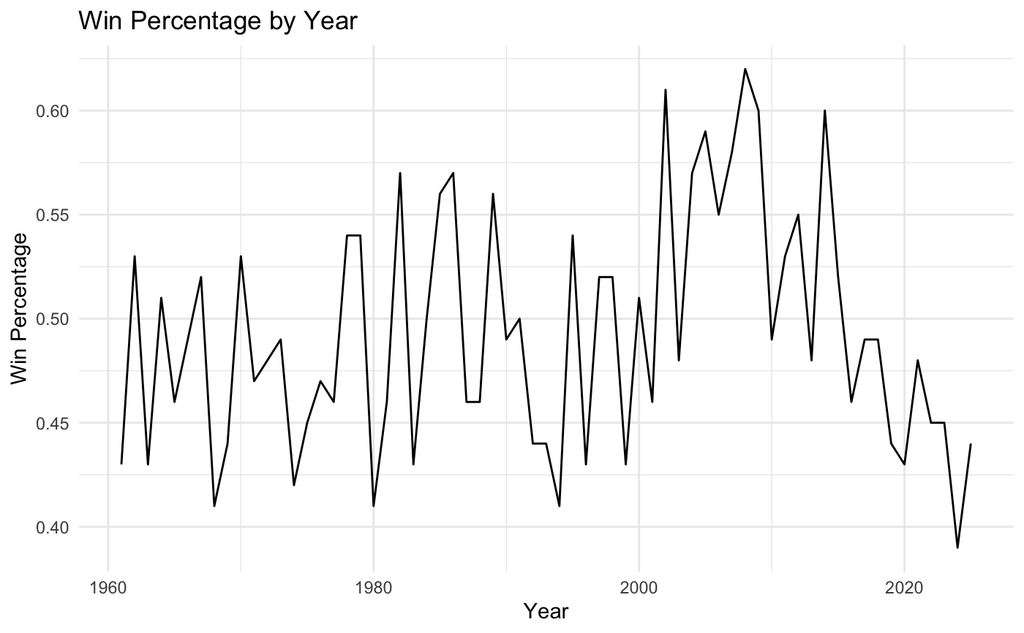

```r
ggplot(AngelsAttendance, aes(x = Year, y = WinPerc)) +
  geom_line() +
  labs(title = "Win Percentage by Year", x = "Year", y = "Win Percentage") +
  theme_minimal()
```

I will use the data excluding 2020 and 2021 since attendance figures were low during those years:

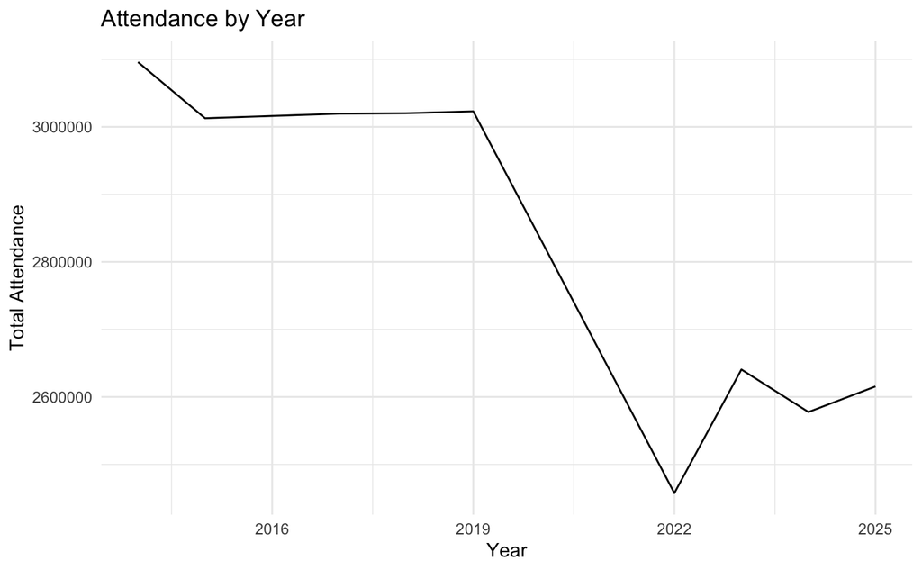

```r
ggplot(LAAAttPlayoffsNoCOVID, aes(x = Year, y = Attendance)) +
  geom_line() +
  labs(title = "Attendance by Year", x = "Year", y = "Total Attendance") +
  theme_minimal()
```

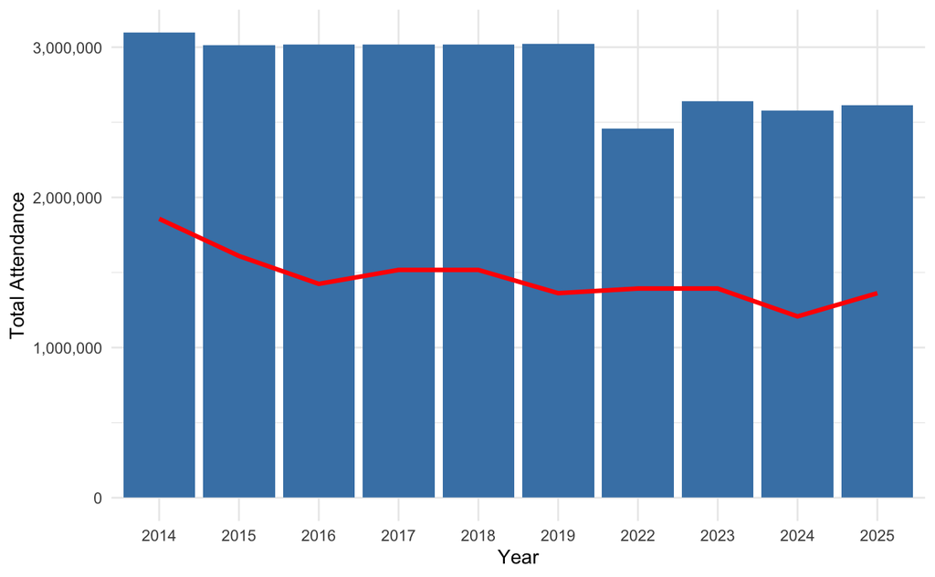

```r
ggplot(LAAAttPlayoffsNoCOVID, aes(x = factor(Year), y = Attendance)) +
  geom_bar(stat = "identity", fill = "steelblue") +
  geom_line(aes(y = WinPerc*max(Attendance), group = 1), color = "red", linewidth = 1.2) +
  labs(x = "Year", y = "Total Attendance") +
  scale_y_continuous(labels = comma) +
  theme_minimal()
```

```r
LAAAttPlayoffsNoCOVID$win_group <- cut(
  LAAAttPlayoffsNoCOVID$W,
  breaks = c(60, 70, 80, 90, 110),
  labels = c("60-69", "70-79", "80-89", "90-110"),
  right = FALSE
)
```

```r
AngelsAttNOCOVID$win_group <- cut(
  AngelsAttNOCOVID$W,
  breaks = c(60, 70, 80, 90, 110),
  labels = c("60-69", "70-79", "80-89", "90-110"),
  right = FALSE
)
```

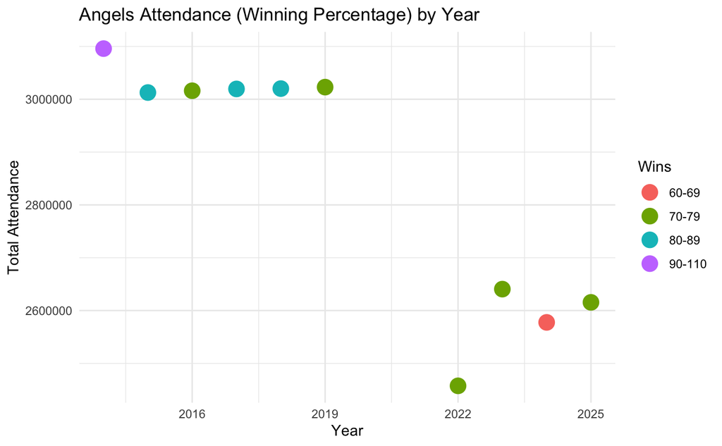

```r
ggplot(LAAAttPlayoffsNoCOVID, aes(x = Year, y = Attendance, color = win_group)) +
  geom_point(size = 5) +
  scale_fill_manual(values = c(
      "60-69" ="black",
      "70-79" ="blue",
      "80-89" ="green",
      "90-110" ="red")) +
labs(x = "Year", y = "Total Attendance", color = "Wins", title = "Angels Attendance (Winning Percentage) by Year") +
theme_minimal()
```

Angels have never lost 100 games. The NAs are the 1981 and 1994 seasons, which were shortened.

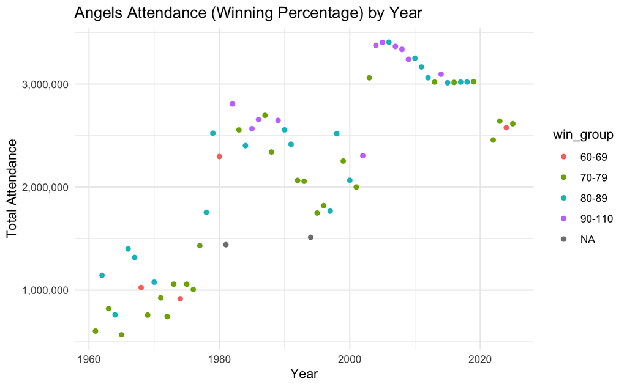

```r
ggplot(AngelsAttNOCOVID, aes(x = Year, y = Attendance, color = win_group)) +
  geom_point() +
 scale_fill_manual(values = c(
      "60-69" ="black",
      "70-79" ="blue",
      "80-89" ="green",
      "90-110" ="red")) +
   labs(x = "Year", y = "Total Attendance", title = "Angels Attendance (Winning Percentage) by Year") +
    scale_y_continuous(labels = comma) +
  theme_minimal()
```

On the side, I wanted to see how many wins the Angels were projected to win at the time I did this side project

July 10, 2026: Record 36-56 Runs Scored: 399 Runs Allowed: 457

Pythagorean Expectation: W%=[(Runs Scored)^1.81]/[(Runs Scored)^1.81 + (Runs Allowed)^1.81]

```r
PE = (399^1.81)/(399^1.81+457^1.81)
PE*162
```

```
[1] 71.10063
```

projected_wins <- current_wins + (remaining_games * current_win_pct)

```r
ProjectedWins <- 36 + (70 * .391)
ProjectedWins
```

```
[1] 63.37
```

```r
36 + 70*PE
```

```
[1] 66.7225
```